# Évaluation du cours “Géomatique et cartographie avec R”

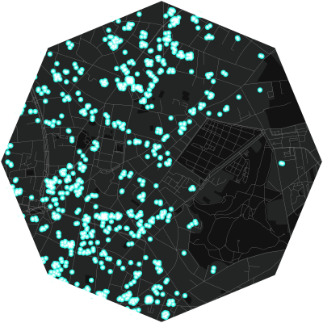

## Analyse des prix des locations Airbnb dans les 12e et 13e arrondissements parisiens

*Louis Laurian & Elina Marveaux*

### Présentation et préparation de l’espace de travail (4 points)

Vous devez tout d’abord télécharger le projet **exam_r** sur votre machine puis le dézipper.

[figure not shown]

Vous devez ensuite renommer le fichier **NOM_Prenom.R** avec vos propres noms et prénoms.  
C’est ce fichier et uniquement ce fichier que vous devrez nous envoyer avant le **31 janvier 2025**.

Assurez vous bien que le script fonctionne avant de nous envoyer le fichier. Pour cela vous pouvez relancer votre session R (ctrl+shift+F10) puis relancer le script. Vous pouvez aussi faire jouer votre script par l’un ou l’une de vos camarades.

Vous devez apporter un soin particulier à la présentation du code. Il doit être lisible, aéré, et commenté.

Vous devrez également soigner la présentation des cartes. Faites attention à l’othographe et n’oubliez pas les éléments d’habillage nécessaires.

### Importer les couches d’information et les cartographier (4 points)

Ces données ont été téléchargées et processées en amont sur le fichier *Preparation_des_donnees.md*, à titre indicatif.

Sur cette carte vous devez faire figurer les limites communales des arrondissements donnés, les espaces verts, le réseau viaire, le réseau ferré et les positions des locations disponibles sur le site en septembre 2024. Vous devrez ajouter à cette carte un habillage complet (flèche d’orientation, échelle, titre, sources…).

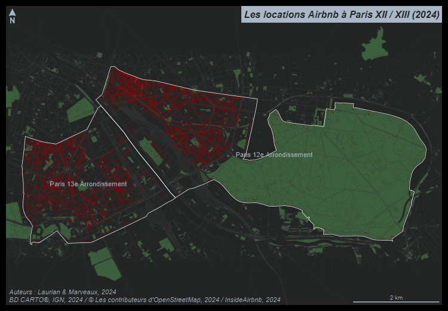

Exemple de carte présentant l’ensemble des couches

### Carte des prix des locations (4 points)

Créez une carte ou chaque location apparait sous la forme d’un point coloré en fonction de son prix.  
Exportez cette carte en PNG avec une largeur de 750 pixels.  
Attention nous ne demandons pas la carte elle-même, uniquement le code qui a servi à la produire.  
Vous devrez justifier la méthode de discrétisation que vous utilisez.

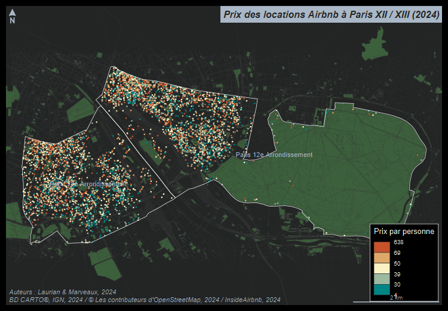

Exemple de brouillon de carte des prix

### Prix par personne dans le voisinage du MK2 Bibliothèque (4 points)

Quel est le **prix médian par personne** dans une zone de 600 mètres autour du MK2 Bibliothèque (**coordonnées WGS84 : Y=48.8326, X=2.3752**)?

### Utilisation d’un maillage régulier (4 points)

Créez un maillage régulier de carreaux de 200 mètres de côté sur les communes étudiées.  
Comptez le nombre de transaction dans chacun des carreaux.  
Calculez le **prix médian par personne** par carreau.  
Construire un carte représentant le prix médian par carreau en n’affichant que les carreaux ayant plus de 5 locations.  
Exportez cette carte en PNG avec une largeur de 750 pixels.  
Attention nous ne demandons pas la carte elle-même, uniquement le code qui a servi à la produire.  
Justifiez la discrétisation utilisée.

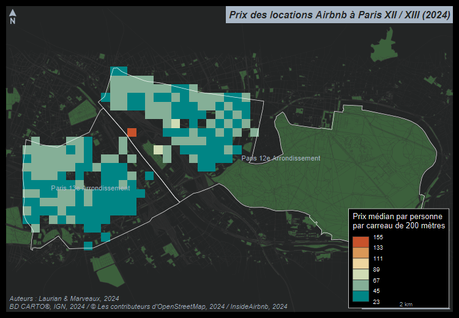

Exemple de brouillon de carte utilisant le maillage régulier